# Lab 3

```r
#The lag plots follow the trend for each of the lagsstarting from 1 to 12
```

3. Decompose the data set and comment on each component. Compare your answers with your answers to part 1.

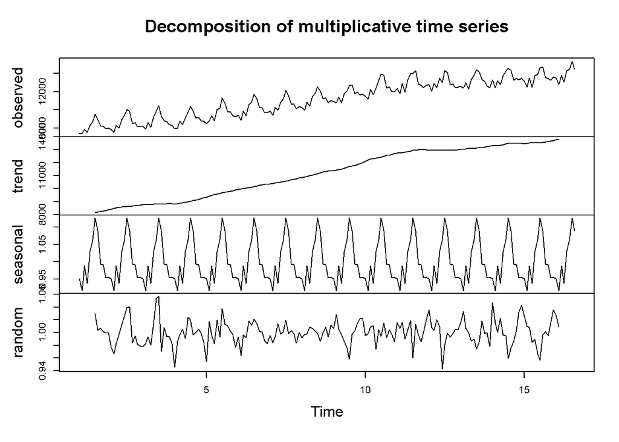

```r
tsa = ts(auselec, frequency = 12)
decompose_tsa = decompose(tsa, "multiplicative")
plot(decompose_tsa)
```

```r
#The decomposition proves that both the timeseries are multiplicative
```

(b). Subtract the seasonal component from the original process and plot it and the original graph in the same window. Comment.

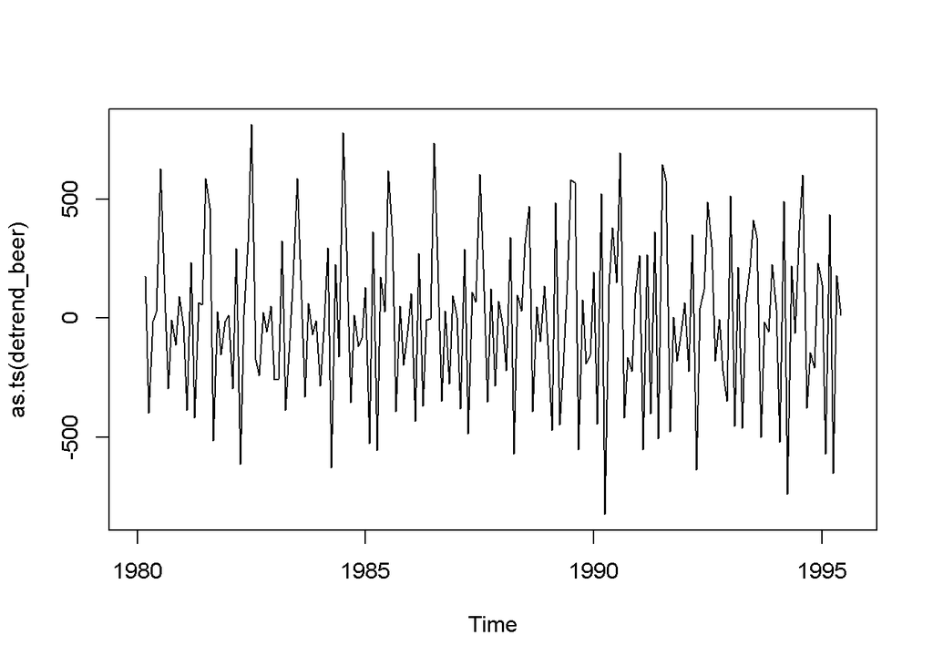

```r
library(forecast)
trend_beer = ma(auselec, order = 4, centre = T)

detrend_beer = auselec - trend_beer
plot(as.ts(detrend_beer))
```

```r
#The plot is not additive
```

(c). Divide the trend component from the original process and plot it and the original graph in the same window. Comment.

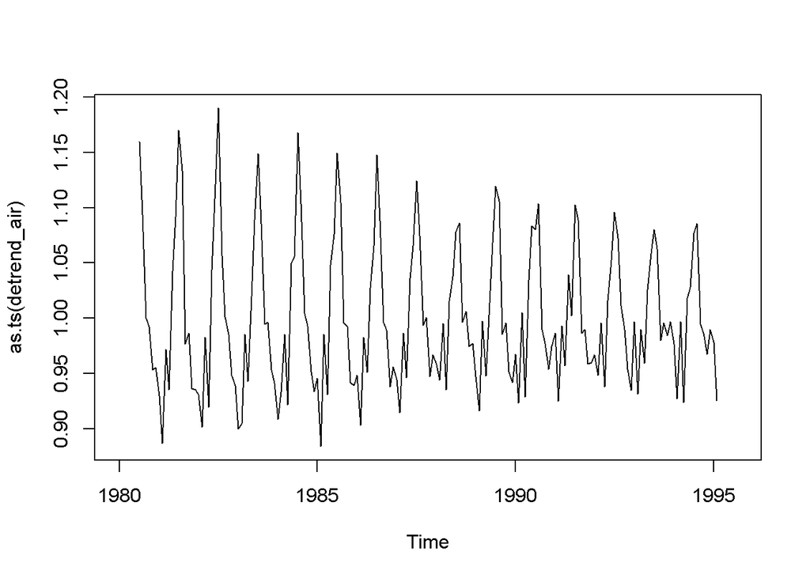

```r
library(forecast)
trend_air = ma(auselec, order = 12, centre = T)

detrend_air = auselec / trend_air
plot(as.ts(detrend_air))
```

```r
#The plot follows a multiplicative trend
```

(d). Is one of these methods (b) or (c) not entirely correct? If so, which one? #method b is not correct